# Untitled

```r
sum(is.na(model_knn$resample$`Precision [thresh = 0.2]`))
```

```
## [1] 53
```

The selection of k using this custom metric and cross-validation is shown below

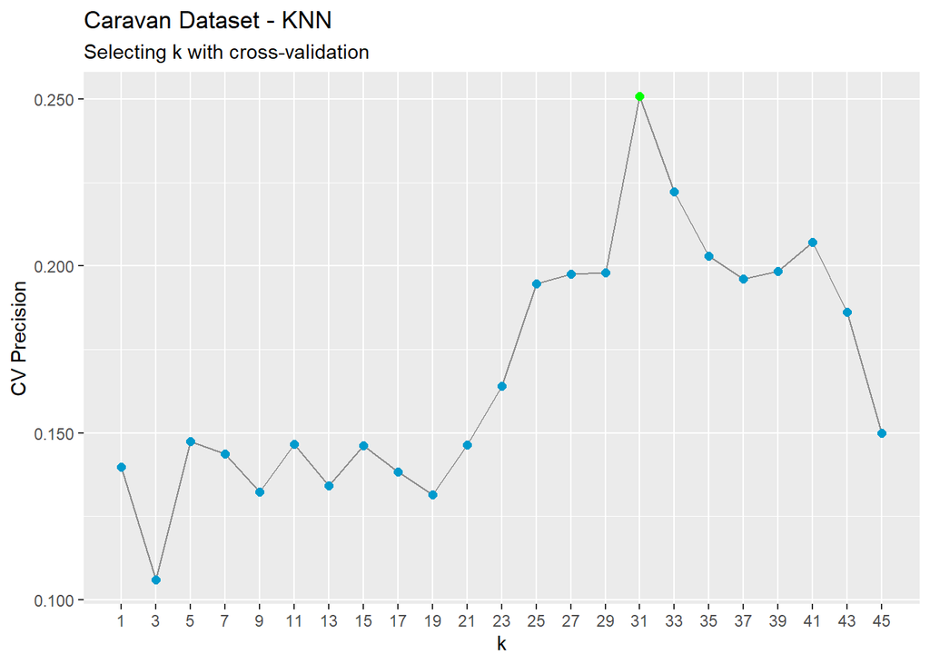

```r
data.frame(k = model_knn$results$k,
           CV_Precision = model_knn$results$`Precision [thresh = 0.2]`) %>%
  mutate(max_CV_Precision = as.numeric(max(CV_Precision) == CV_Precision)) %>%
  ggplot(aes(x = k, y = CV_Precision)) +
  geom_line(col = "grey55") +
  geom_point(size = 2, aes(col = factor(max_CV_Precision))) +
  scale_x_continuous(breaks = seq(1, 45, 2), minor_breaks = NULL) +
  scale_y_continuous(labels = scales::comma_format()) +
  scale_color_manual(values = c("deepskyblue3", "green")) +
  theme(legend.position = "none") +
  labs(title = "Caravan Dataset - KNN",
       subtitle = "Selecting k with cross-validation",
       y = "CV Precision")
```

For k = 31, the cross-validation Precision:

```r
max(model_knn$results$`Precision [thresh = 0.2]`) %>% round(4)
```

```
## [1] 0.2508
```

The confusion matrix for test:

```r
predicted <- factor(ifelse(predict(model_knn, test, "prob")$Yes > 0.2, "Yes", "No")) %>% relevel(ref = "Yes")
actual <- test$Purchase %>% relevel(ref = "Yes")

conf_matrix <- table(predicted, actual)
conf_matrix
```

```
##          actual
## predicted  Yes   No
##       Yes   16   59
##       No   273 4474
```

Here’s the resulting test precision:

```r
# precision = TP / (TP + FP)
precision <- conf_matrix[1, 1] / (conf_matrix[1, 1] + conf_matrix[1, 2])
precision %>% round(4)
```

```
## [1] 0.2133
```

**Logistic Regression**

```r
set.seed(5)

model_logistic <- train(Purchase ~ .,
                        data = train,
                        method = "glm",
                        metric = "Precision [thresh = 0.2]",
                        maximize = T,
                        family = "binomial",
                        trControl = ctrl)
```

The cross-validation Precision:

```r
model_logistic$results$`Precision [thresh = 0.2]` %>% round(4)
```

```
## [1] 0.1402
```

The confusion matrix for test:

```r
predicted <- factor(ifelse(predict(model_logistic, test, "prob")$Yes > 0.2, "Yes", "No")) %>% relevel(ref = "Yes")
actual <- test$Purchase %>% relevel(ref = "Yes")

conf_matrix <- table(predicted, actual)
conf_matrix
```

```
##          actual
## predicted  Yes   No
##       Yes   58  350
##       No   231 4183
```

Here’s the resulting test precision:

```r
precision <- conf_matrix[1, 1] / (conf_matrix[1, 1] + conf_matrix[1, 2])
precision %>% round(4)
```

```
## [1] 0.1422
```

## Problem 12

```r
glimpse(Boston)
```

```
## Rows: 506
## Columns: 14
## $ crim    <dbl> 0.00632, 0.02731, 0.02729, 0.03237, 0.06905, 0.02985, 0.08829,~
## $ zn      <dbl> 18.0, 0.0, 0.0, 0.0, 0.0, 0.0, 12.5, 12.5, 12.5, 12.5, 12.5, 1~
## $ indus   <dbl> 2.31, 7.07, 7.07, 2.18, 2.18, 2.18, 7.87, 7.87, 7.87, 7.87, 7.~
## $ chas    <int> 0, 0, 0, 0, 0, 0, 0, 0, 0, 0, 0, 0, 0, 0, 0, 0, 0, 0, 0, 0, 0,~
## $ nox     <dbl> 0.538, 0.469, 0.469, 0.458, 0.458, 0.458, 0.524, 0.524, 0.524,~
## $ rm      <dbl> 6.575, 6.421, 7.185, 6.998, 7.147, 6.430, 6.012, 6.172, 5.631,~
## $ age     <dbl> 65.2, 78.9, 61.1, 45.8, 54.2, 58.7, 66.6, 96.1, 100.0, 85.9, 9~
## $ dis     <dbl> 4.0900, 4.9671, 4.9671, 6.0622, 6.0622, 6.0622, 5.5605, 5.9505~
## $ rad     <int> 1, 2, 2, 3, 3, 3, 5, 5, 5, 5, 5, 5, 5, 4, 4, 4, 4, 4, 4, 4, 4,~
## $ tax     <dbl> 296, 242, 242, 222, 222, 222, 311, 311, 311, 311, 311, 311, 31~
## $ ptratio <dbl> 15.3, 17.8, 17.8, 18.7, 18.7, 18.7, 15.2, 15.2, 15.2, 15.2, 15~
## $ black   <dbl> 396.90, 396.90, 392.83, 394.63, 396.90, 394.12, 395.60, 396.90~
## $ lstat   <dbl> 4.98, 9.14, 4.03, 2.94, 5.33, 5.21, 12.43, 19.15, 29.93, 17.10~
## $ medv    <dbl> 24.0, 21.6, 34.7, 33.4, 36.2, 28.7, 22.9, 27.1, 16.5, 18.9, 15~
```

**Linear Regression**

```r
names(Boston)
```

```
##  [1] "crim"    "zn"      "indus"   "chas"    "nox"     "rm"      "age"
##  [8] "dis"     "rad"     "tax"     "ptratio" "black"   "lstat"   "medv"
```

```r
ctrl <- trainControl(method = "repeatedcv", number = 10, repeats = 10 , summaryFunction = custom_regression_metrics)

set.seed(1)

model_linear_1 <- train(crim ~ zn + nox + dis + rad + ptratio + black + medv,
                        data = Boston,
                        method = "lm",
                        trControl = ctrl)

model_linear_1$results$MSE %>% round(2)
```

```
## [1] 42.78
```

**Linear Regression (Best-Subset Selection, Manual Transformations):**

```r
Boston_1 <- Boston

Boston_1$medv_sq <- Boston_1$medv^2
Boston_1$medv_cub <- Boston_1$medv^3

Boston_1$rad_cat <- ifelse(Boston_1$rad > 20, 1, 0)
Boston_1$rad <- NULL
Boston_1$tax <- NULL


set.seed(1)

model_linear_2 <- train(crim ~ nox + dis + ptratio + medv + medv_sq + medv_cub + rad_cat,
                        data = Boston_1,
                        method = "lm",
                        trControl = ctrl)

model_linear_2$results$MSE %>% round(2)
```

```
## [1] 35.23
```

**Generalized Additive Models**

```r
set.seed(1)

model_smoothspline <- train(crim ~ .,
                            data = Boston,
                            method = "gamSpline",
                            maximize = F,
                            metric = "MSE",
                            trControl = ctrl,
                            tuneGrid = data.frame(df = 4.9))

model_smoothspline$results$MSE %>% round(2)
```

```
## [1] 35.26
```

**Bagging**

```r
set.seed(1)

model_bagging <- train(crim ~ .,
                       data = Boston,
                       method = "rf",
                       metric = "MSE",
                       maximize = F,
                       trControl = ctrl,
                       tuneGrid = expand.grid(mtry = 13))

model_bagging$results$MSE %>% round(2)
```

```
## [1] 39.25
```

**Random Forest**

```r
set.seed(1)

model_rf <- train(crim ~ .,
                  data = Boston,
                  method = "rf",
                  metric = "MSE",
                  maximize = F,
                  trControl = ctrl,
                  tuneGrid = expand.grid(mtry = 2))

model_rf$results$MSE %>% round(2)
```

```
## [1] 33.53
```

**Boosting**

```r
gbm_grid <- expand.grid(n.trees = 3400, interaction.depth = 5, n.minobsinnode = 10, shrinkage = 0.001)

set.seed(1)

model_gbm <- train(crim ~ .,
                   data = Boston,
                   method = "gbm",
                   distribution = "gaussian",
                   verbose = F,
                   metric = "MSE",
                   maximize = F,
                   trControl = ctrl,
                   tuneGrid = gbm_grid)


model_gbm$results$MSE %>% round(2)
```

```
## [1] 33.66
```

**Comparison**

```r
model_summary_resamples <- data.frame(method = "Linear Reg.", MSE = model_linear_1$resample$MSE) %>%
  rbind(data.frame(method = "Linear Reg. (Transformations)", MSE = model_linear_2$resample$MSE)) %>%
  rbind(data.frame(method = "GAM (Smooth Terms)", MSE = model_smoothspline$resample$MSE)) %>%
  rbind(data.frame(method = "Bagged Trees", MSE = model_bagging$resample$MSE)) %>%
  rbind(data.frame(method = "Random Forest", MSE = model_rf$resample$MSE)) %>%
  rbind(data.frame(method = "GBM", MSE = model_gbm$resample$MSE))

model_summary <- model_summary_resamples %>%
  group_by(method) %>%
  summarize(MSE = mean(MSE)) %>%
  arrange(MSE) %>%
  mutate(MSE = round(MSE, 2))

model_summary
```

```
## # A tibble: 6 x 2
##   method                          MSE
##   <chr>                         <dbl>
## 1 Random Forest                  33.5
## 2 GBM                            33.7
## 3 Linear Reg. (Transformations)  35.2
## 4 GAM (Smooth Terms)             35.3
## 5 Bagged Trees                   39.2
## 6 Linear Reg.                    42.8
```